# BlackSheep outlier analysis results for proteome

## Overview

This report summarizes the significant results for proteome (FDR < 0.05) of the BlackSheep module, which uses the blacksheepr package for differential extreme value analysis. Briefly, this module counts outliers in user-submitted data, tabulates outliers per group, and runs enrichment analysis (Fisher’s exact test) to identify significant outliers in the groups of interest. More information about the BlackSheep algorithm can be found in Blumenberg et al. (2019, [preprint](https://www.biorxiv.org/content/10.1101/825067v2.full.pdf)), and detailed documentation of the panoply_blacksheep module can be found [here](https://github.com/broadinstitute/PANOPLY/wiki/Analysis-Modules%3A-panoply_blacksheep).

## Positive outliers (FDR < 0.05)

### PAM50

#### **PAM50: Basal**

Number of significant genes: 42

**Table**: Significant genes ranked by FDR value.

| gene | fdr |
| --- | --- |
| MTHFD1L | 2.08e-11 |
| NDRG2 | 1.86e-08 |
| CLASP1 | 1.22e-07 |
| GLS | 1.22e-07 |
| SOX10 | 7.96e-07 |
| PTX3 | 2.11e-06 |
| CEP170 | 8.56e-06 |
| DMD | 1.09e-05 |
| HAPLN1 | 1.09e-05 |
| PLA2G4A | 1.09e-05 |

[output cut: 32 more lines]

**Figure**: Heatmap depicting the fraction of outliers within each significant gene for each sample. Sample annotations are ordered by PAM50. Note: row names may not be annotated if there are more than 100 significant genes.

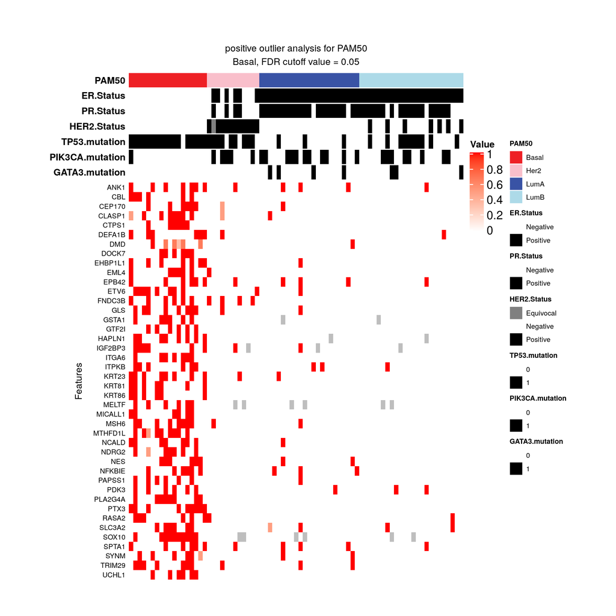

#### **PAM50: Her2**

Number of significant genes: 32

**Table**: Significant genes ranked by FDR value.

| gene | fdr |
| --- | --- |
| OSBPL2 | 0.00136 |
| ERBB2 | 0.00142 |
| G6PD | 0.00345 |
| PITPNM1 | 0.00345 |
| PNMT | 0.00345 |
| SPTLC2 | 0.00345 |
| THEM6 | 0.00345 |
| GALNT3 | 0.00473 |
| MUC6 | 0.00473 |
| POLDIP2 | 0.00473 |

[output cut: 22 more lines]

**Figure**: Heatmap depicting the fraction of outliers within each significant gene for each sample. Sample annotations are ordered by PAM50. Note: row names may not be annotated if there are more than 100 significant genes.

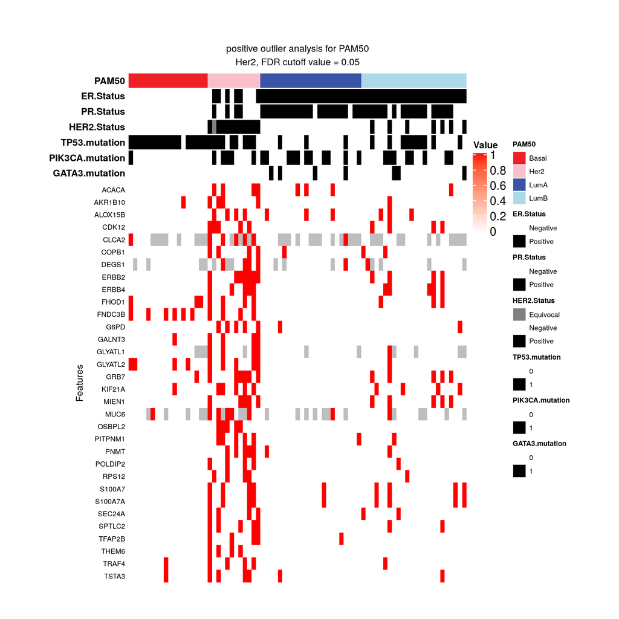

#### **PAM50: LumA**

Number of significant genes: 5

**Table**: Significant genes ranked by FDR value.

| gene | fdr |
| --- | --- |
| TPRG1 | 0.000206 |
| AMPH | 0.000211 |
| GLA | 0.000211 |
| HBP1 | 0.000211 |
| CLIC6 | 0.000652 |

**Figure**: Heatmap depicting the fraction of outliers within each significant gene for each sample. Sample annotations are ordered by PAM50. Note: row names may not be annotated if there are more than 100 significant genes.

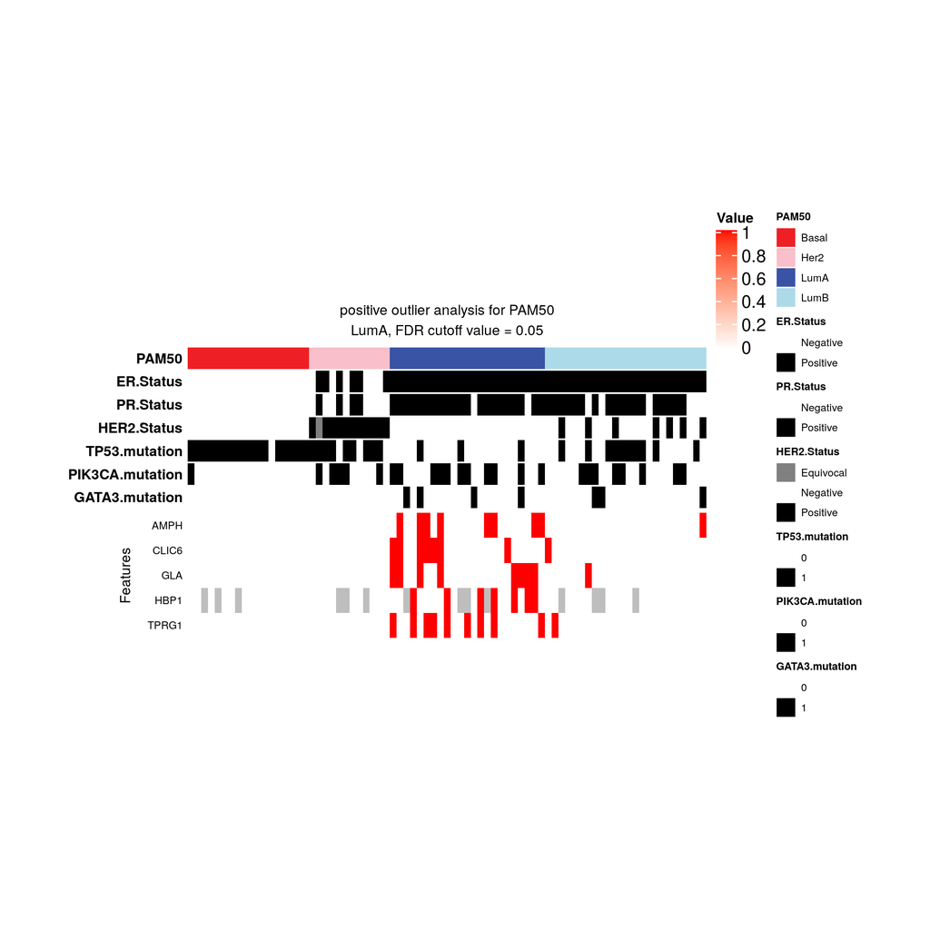

#### **PAM50: LumB**

Number of significant genes: 1

**Table**: Significant genes ranked by FDR value.

| gene | fdr |
| --- | --- |
| TRIM36 | 0.00114 |

**Figure**: Heatmap depicting the fraction of outliers within each significant gene for each sample. Sample annotations are ordered by PAM50. Note: row names may not be annotated if there are more than 100 significant genes.

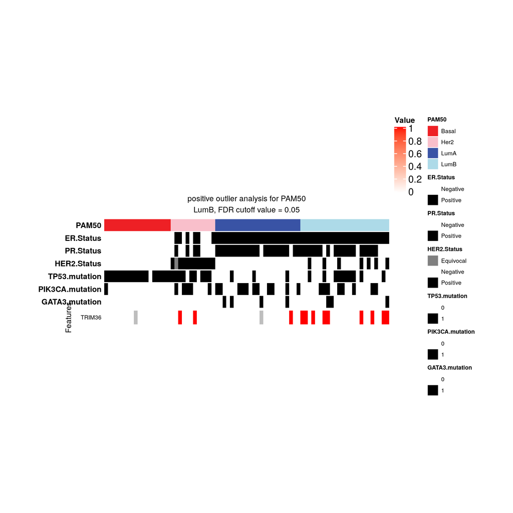

### ER.Status

#### **ER.Status: Negative**

Number of significant genes: 13

**Table**: Significant genes ranked by FDR value.

| gene | fdr |
| --- | --- |
| MTHFD1L | 3.18e-09 |
| GLS | 4.28e-08 |
| CLASP1 | 4.27e-07 |
| SOX10 | 8.05e-06 |
| PTX3 | 2.11e-05 |
| PLA2G4A | 7.57e-05 |
| HAPLN1 | 8.1e-05 |
| FNDC3B | 0.000106 |
| ETV6 | 0.00107 |
| KRT23 | 0.00107 |

[output cut: 3 more lines]

**Figure**: Heatmap depicting the fraction of outliers within each significant gene for each sample. Sample annotations are ordered by ER.Status. Note: row names may not be annotated if there are more than 100 significant genes.

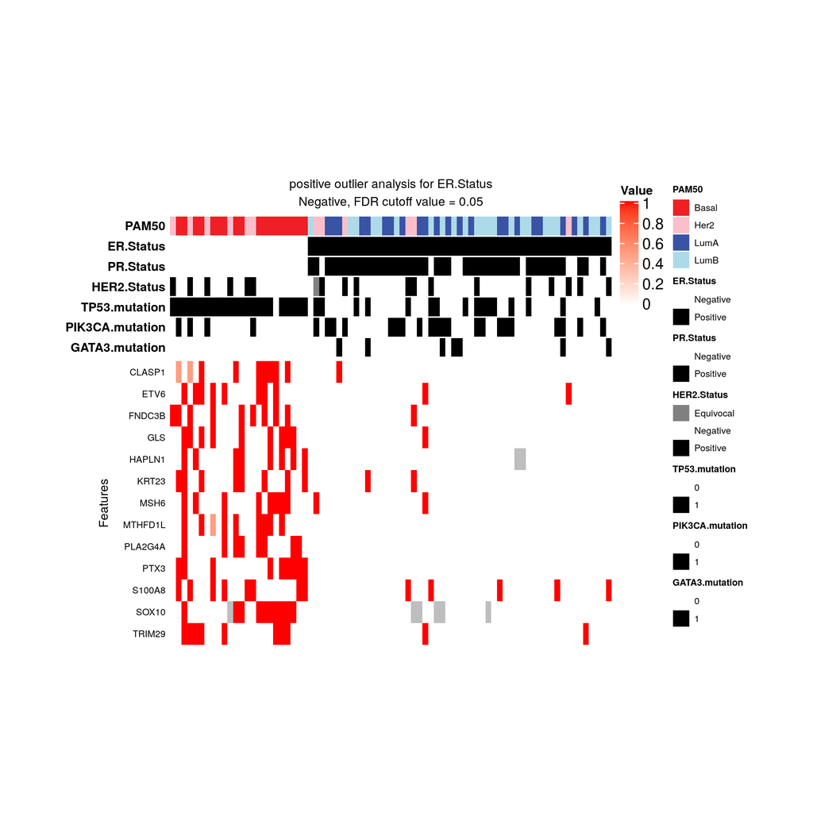

#### **ER.Status: Positive**

Number of significant genes: 0

### HER2.Status

#### **HER2.Status: Negative**

Number of significant genes: 0

#### **HER2.Status: Positive**

Number of significant genes: 16

**Table**: Significant genes ranked by FDR value.

| gene | fdr |
| --- | --- |
| ERBB2 | 8.1e-08 |
| GRB7 | 2.92e-07 |
| MIEN1 | 2.92e-07 |
| CDK12 | 5.54e-05 |
| SPTLC2 | 5.54e-05 |
| ERBB4 | 0.000201 |
| CSTF3 | 0.000885 |
| PNMT | 0.000885 |
| SPTLC1 | 0.000885 |
| FBXL20 | 0.00103 |

[output cut: 6 more lines]

**Figure**: Heatmap depicting the fraction of outliers within each significant gene for each sample. Sample annotations are ordered by HER2.Status. Note: row names may not be annotated if there are more than 100 significant genes.

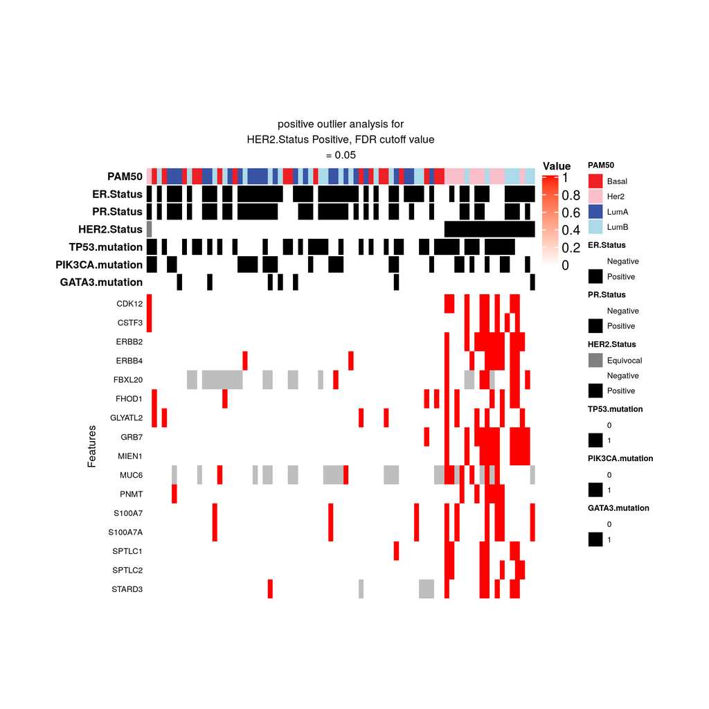

### GATA3.mutation

#### **GATA3.mutation: 0**

Number of significant genes: 0

#### **GATA3.mutation: 1**

Number of significant genes: 29

**Table**: Significant genes ranked by FDR value.

| gene | fdr |
| --- | --- |
| ADO | 0.00533 |
| ATG16L1 | 0.00533 |
| EMSY | 0.00533 |
| GORAB | 0.00533 |
| HELZ | 0.00533 |
| PIK3R4 | 0.00533 |
| RNPC3 | 0.00533 |
| SERINC1 | 0.00533 |
| SMG5 | 0.00533 |
| VPS33B | 0.00533 |

[output cut: 19 more lines]

**Figure**: Heatmap depicting the fraction of outliers within each significant gene for each sample. Sample annotations are ordered by GATA3.mutation. Note: row names may not be annotated if there are more than 100 significant genes.

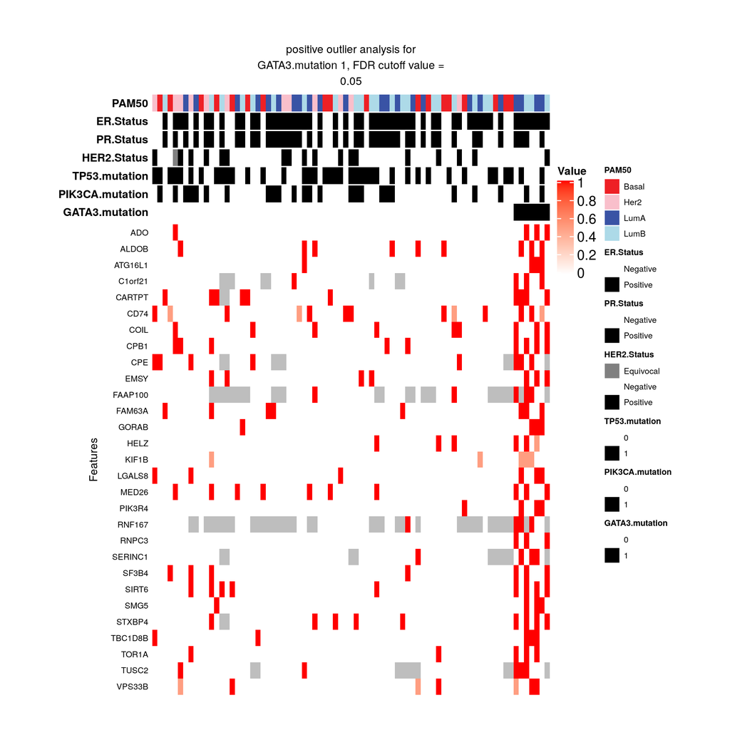

## Negative outliers (FDR < 0.05)

### PAM50

#### **PAM50: Basal**

Number of significant genes: 2

**Table**: Significant genes ranked by FDR value.

| gene | fdr |
| --- | --- |
| RAB11FIP4 | 9.02e-05 |
| FOXA1 | 9.13e-05 |

**Figure**: Heatmap depicting the fraction of outliers within each significant gene for each sample. Sample annotations are ordered by PAM50. Note: row names may not be annotated if there are more than 100 significant genes.

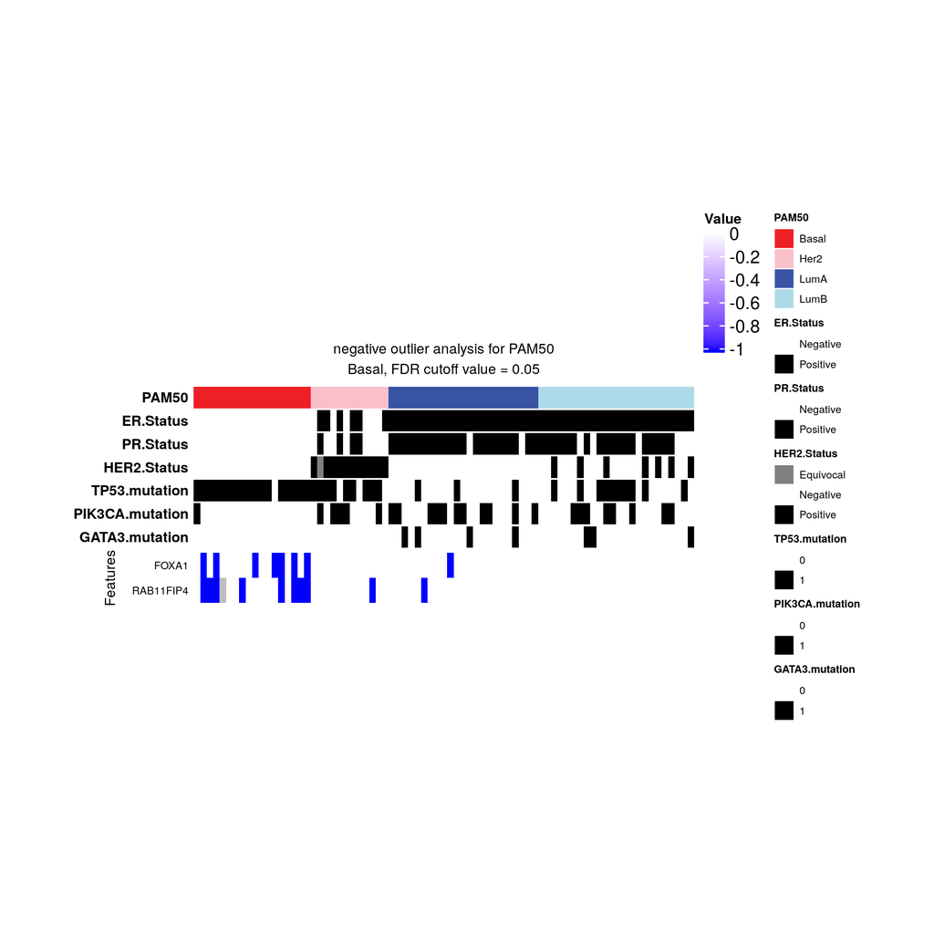

#### **PAM50: Her2**

Number of significant genes: 126

**Table**: Significant genes ranked by FDR value.

| gene | fdr |
| --- | --- |
| WWP2 | 0.000159 |
| AGAP3 | 0.000332 |
| BPTF | 0.000332 |
| HDDC3 | 0.000485 |
| NOLC1 | 0.00105 |
| PPHLN1 | 0.0011 |
| ZC3H14 | 0.00135 |
| HMGN3 | 0.00165 |
| CGN | 0.00262 |
| CHMP4C | 0.00262 |

[output cut: 116 more lines]

**Figure**: Heatmap depicting the fraction of outliers within each significant gene for each sample. Sample annotations are ordered by PAM50. Note: row names may not be annotated if there are more than 100 significant genes.

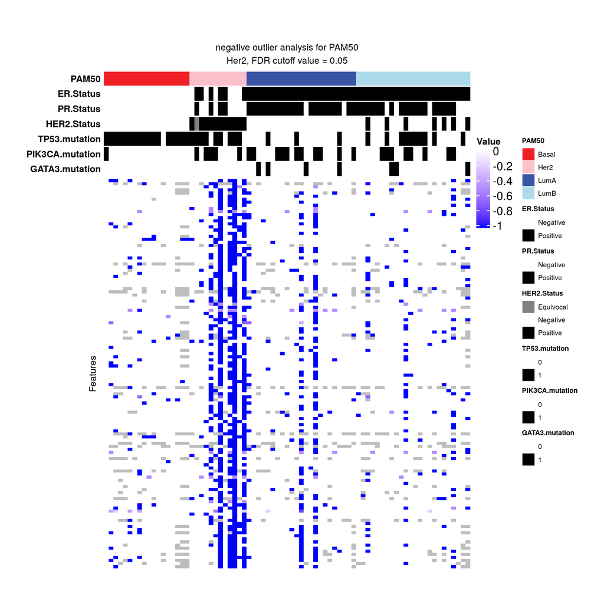

### ER.Status

#### **ER.Status: Negative**

Number of significant genes: 2

**Table**: Significant genes ranked by FDR value.

| gene | fdr |
| --- | --- |
| RAB11FIP4 | 0.00014 |
| CD2BP2 | 0.00148 |

**Figure**: Heatmap depicting the fraction of outliers within each significant gene for each sample. Sample annotations are ordered by ER.Status. Note: row names may not be annotated if there are more than 100 significant genes.

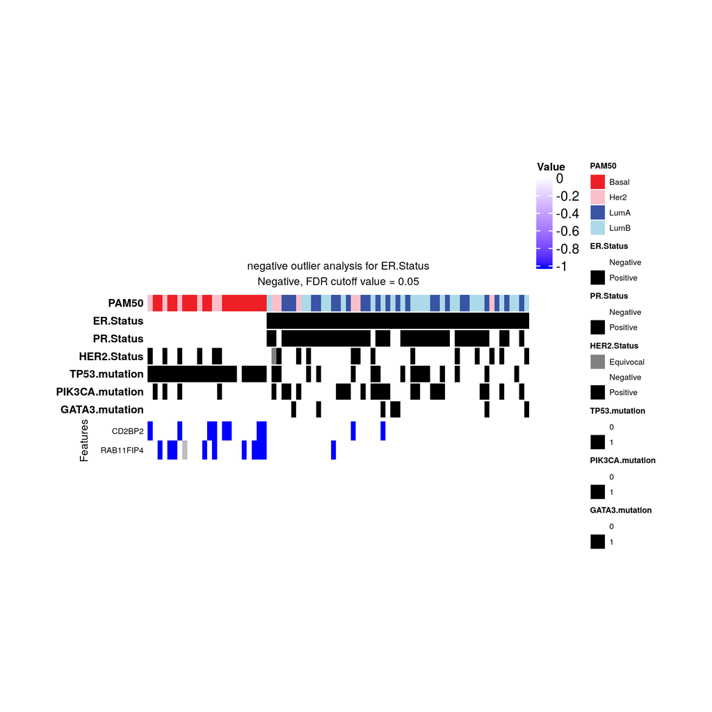

#### **ER.Status: Positive**

Number of significant genes: 0

### HER2.Status

#### **HER2.Status: Negative**

Number of significant genes: 0

#### **HER2.Status: Positive**

Number of significant genes: 51

**Table**: Significant genes ranked by FDR value.

| gene | fdr |
| --- | --- |
| CNBP | 2.67e-05 |
| PPHLN1 | 8.32e-05 |
| RPS10 | 8.32e-05 |
| RHBDF2 | 0.000103 |
| HGS | 0.00017 |
| SURF6 | 0.000327 |
| ATP8A2 | 0.000442 |
| IGF1R | 0.000442 |
| ZMYND11 | 0.000442 |
| ZNF414 | 0.000442 |

[output cut: 41 more lines]

**Figure**: Heatmap depicting the fraction of outliers within each significant gene for each sample. Sample annotations are ordered by HER2.Status. Note: row names may not be annotated if there are more than 100 significant genes.

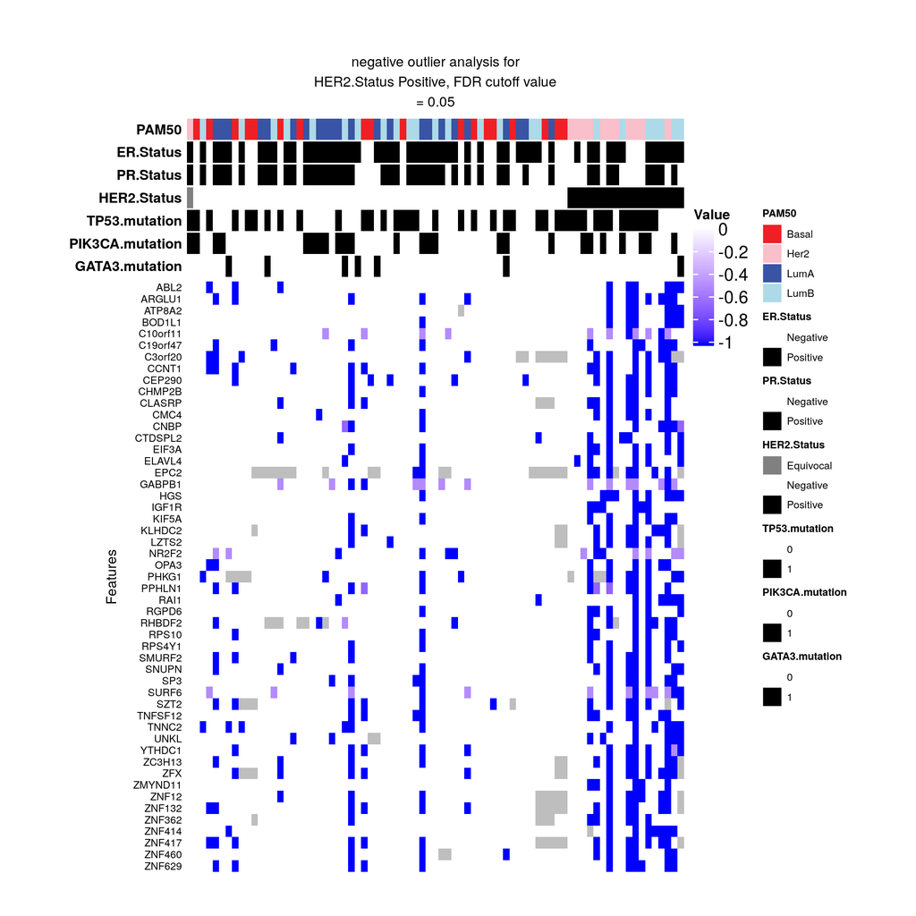

### TP53.mutation

#### **TP53.mutation: 0**

Number of significant genes: 0

#### **TP53.mutation: 1**

Number of significant genes: 0

### GATA3.mutation

#### **GATA3.mutation: 0**

Number of significant genes: 0

#### **GATA3.mutation: 1**

Number of significant genes: 23

**Table**: Significant genes ranked by FDR value.

| gene | fdr |
| --- | --- |
| RBM14 | 0.0023 |
| UFM1 | 0.0023 |
| VPS29 | 0.0023 |
| VHL | 0.00275 |
| CDK14 | 0.0049 |
| MAPK15 | 0.0107 |
| ICK | 0.014 |
| MGMT | 0.014 |
| MTFR1L | 0.014 |
| PABPC1L2B | 0.014 |

[output cut: 13 more lines]

**Figure**: Heatmap depicting the fraction of outliers within each significant gene for each sample. Sample annotations are ordered by GATA3.mutation. Note: row names may not be annotated if there are more than 100 significant genes.

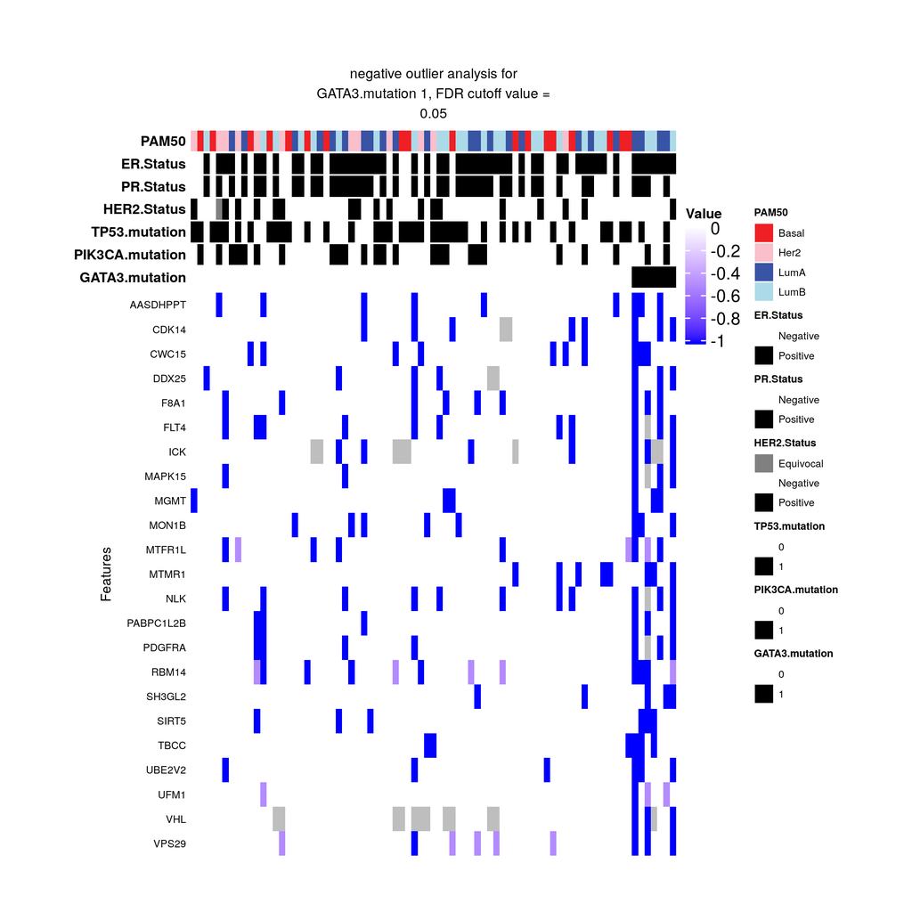